# Architecture_analysis

Marc LABADIE

5 juin 2018

# 1 Requierements

## 1.1 Packages install

```r
install.packages("plyr")
install.packages("ggplot2")
install.packages("gtable")
install.packages("grid")
install.packages("cowplot")
install.packages("reshape2")
install.packages("scales")
install.packages("knitr")
install.packages("tinytex")
install.packages("dplyr")
install.packages("lmtest")
#install.packages("RCurl")
```

## 1.2 Packages loading

```r
library(plyr)
library(ggplot2)
library(gtable)
library(grid)
library(cowplot)
library(reshape2)
library(scales)
library(knitr)
library(tinytex)
library(dplyr)
#library(RCurl)
library(rmarkdown)
library(lmtest)
```

## 1.3 Functions importing

```r
source(file = "c:/Users/mlabadie/Documents/GitHub/strawberry/Rscript/Functions.R")
```

# 2 Import and transformation of dataset

## 2.1 Import dataset

**INDEX_PARAMETER :** TIME # vertex_id

**15 VARIABLES:**

- VARIABLE 1 : INT # nb_visible_leaves. No. elongated leaves (F)
- VARIABLE 2 : INT # nb_foliar_primordia No. primordia (f)
- VARIABLE 3 : INT # nb_total_leaves. Total no. leaves (F+f)
- VARIABLE 4 : INT # nb_open_flowers. No. open flowers
- VARIABLE 5 : INT # nb_aborted_flowers No. aborted flowers
- VARIABLE 6 : INT # nb_total_flowers Total no. flowers
- VARIABLE 7 : INT # vegetative_bud. No. vegetative buds (axillary vegetative bud)
- VARIABLE 8 : INT # Initiated_bud. No. initiated bud (axillary initiated bud)
- VARIABLE 9 : INT # floral_bud. No. floral buds (axillary floral bud)
- VARIABLE 10 : INT # stolons No. stolons
- VARIABLE 11 : INT # type_of_crown. Type of crown (1: primary crown, 2: extention crowns, 3: branch crown)
- VARIABLE 12 : INT # Crown_status (1: Terminal Vegetative bud (bt, stage 17, 18, 19, None), 2:Terminal bud initiated (bt, stage A), 3: Terminal floral bud(ht), 4: Inflorescence(HT), -1: rotten or aborded)
- VARIABLE 13 : INT # genotype (1: Gariguette, 2: Ciflorette, 3: Clery, 4: Capriss, 5:Darselect, 6: Cir107)
- VARIABLE 14 : INT # date (1: mid December, 2: early Junuary, 3: mid February, 4: early March, 5: early April, 6: end May/early June)
- VARIABLE 15 : INT # plant. plant index

```r
DataSet <- read.csv(
  "c:/Users/mlabadie/Documents/GitHub/strawberry/Rscript/Dataset.csv",
  sep=";",na.strings = "-1")

colstart<-1
colend<-dim(DataSet)[2]-2

data<-DataSet[,c(colstart:colend)]
```

## 2.2 Dataset Class Object

```r
str(object = data)
```

```
## 'data.frame':    1796 obs. of  16 variables:
##  $ Index              : Factor w/ 17 levels "0","0-1","0-1-2",..: 1 1 1 1 1 1 1 1 1 1 ...
##  $ nb_visible_leaves  : int  8 8 11 8 6 7 7 6 7 11 ...
##  $ nb_foliar_primordia: int  4 4 3 3 4 4 4 3 3 8 ...
##  $ nb_total_leaves    : int  12 12 14 11 10 11 11 9 10 19 ...
##  $ nb_open_flowers    : int  0 0 0 0 0 0 0 0 0 0 ...
##  $ nb_aborted_flowers : int  0 0 0 0 0 0 0 0 0 0 ...
##  $ nb_total_flowers   : int  0 0 0 0 0 0 0 0 0 0 ...
##  $ vegetative_bud     : int  1 4 3 6 5 3 7 1 4 3 ...
##  $ Initiated_bud      : int  3 3 1 0 2 2 1 3 0 2 ...
##  $ floral_bud         : int  7 4 8 5 2 5 2 4 5 10 ...
##  $ stolons            : int  1 1 2 0 1 1 1 1 1 1 ...
##  $ type_of_crown      : int  1 1 1 1 1 1 1 1 1 1 ...
##  $ Crown_status       : int  3 3 3 3 3 3 3 3 3 3 ...
##  $ genotype           : int  1 1 1 1 1 1 1 1 1 1 ...
##  $ date               : int  1 1 1 1 1 1 1 1 1 2 ...
##  $ plant              : int  1 2 3 4 5 6 7 8 9 1 ...
```

## 2.3 Transformation of Class object

```r
data$genotype<- as.factor(data$genotype)
data$date<- as.factor(DataSet$date)
data$Crown_status<- as.factor(DataSet$Crown_status)
data$type_of_crown<- as.factor(DataSet$type_of_crown)
```

## 2.4 Conversion of dataset

```r
# Convert numerical categorical ordered value in factor values with their properties

data$genotype<- factor(x = data$genotype,
                       levels = levels(x = data$genotype),
                       labels = c("Gariguette","Ciflorette","Clery","Capriss","Darselect","Cir107")
                       )

data$date<- factor(x = data$date,
                   levels = levels(x = data$date),
                   labels = c("Mid-December","Early-Junuary","Mid-February","Early-March","Early-April","Early-June")
                   )

data$type_of_crown<- factor(x = DataSet$type_of_crown,
                            levels = levels(x = data$type_of_crown),
                            labels = c("Primary_Crown","Extention_Crown","Branch_Crown")
                            )
data$Crown_status<- factor(x = data$Crown_status,
                              levels = levels(x = data$Crown_status),
                              labels = c("Terminal_Vegetative_bud","Terminal_initiated_bud","Terminal_Floral_bud","Terminal_Inflorescence"))
```

```r
#convert index sequence analysis in index for R analysis
dat<-data[2:colend]
for (i in 1:nrow(data)){
  if (data[i,'Index']=="0"){
    dat[i,"Index"]<- 0
  }else if (data[i,'Index']=="0-1"){
    dat[i,"Index"]<- 1
  }else if (data[i,'Index']=="0-1-2"){
    dat[i,"Index"]<- 2
  }else if (data[i,'Index']=="0-1-2-3"){
    dat[i,"Index"]<- 3
  }else if (data[i,'Index']=="0-1-2-3-4"){
    dat[i,"Index"]<- 4
  }else if (data[i,'Index']=="0-1-2-3-4-5"){
    dat[i,"Index"]<- 5
  }else if (data[i,'Index']=="1"){
    dat[i,"Index"]<- 1
  }else if (data[i,'Index']=="1-2"){
    dat[i,"Index"]<- 2
  }else if (data[i,'Index']=="1-2-3"){
    dat[i,"Index"]<- 3
  }else if (data[i,'Index']=="1-2-3-4"){
    dat[i,"Index"]<- 4
  }else if (data[i,'Index']=="1-2-3-4-5"){
    dat[i,"Index"]<- 5
  }else if (data[i,'Index']=="2"){
    dat[i,"Index"]<- 2
  }else if (data[i,'Index']=="2-3"){
    dat[i,"Index"]<- 3
  }else if (data[i,'Index']=="2-3-4"){
    dat[i,"Index"]<- 4
  }else if (data[i,'Index']=="3"){
    dat[i,"Index"]<- 3
  }else if (data[i,'Index']=="3-4"){
    dat[i,"Index"]<- 4
  }else if (data[i,'Index']=="4"){
    dat[i,"Index"]<- 4
  }
}

dat$Index<-as.factor(x = dat$Index)

#Remplacer les valeurs 0 dans la colone total flowers par NA
dat$nb_total_flowers[dat$nb_total_flowers==0]<-NA

kable(x = dat,digits = 2,caption = "Data extract from MTG")
```

Data extract from MTG

| nb_visible_leaves | nb_foliar_primordia | nb_total_leaves | nb_open_flowers | nb_aborted_flowers | nb_total_flowers | vegetative_bud | Initiated_bud | floral_bud | stolons | type_of_crown | Crown_status | genotype | date | plant | Index |
| --- | --- | --- | --- | --- | --- | --- | --- | --- | --- | --- | --- | --- | --- | --- | --- |
| 8 | 4 | 12 | 0 | 0 | NA | 1 | 3 | 7 | 1 | Primary_Crown | Terminal_Floral_bud | Gariguette | Mid-December | 1 | 0 |
| 8 | 4 | 12 | 0 | 0 | NA | 4 | 3 | 4 | 1 | Primary_Crown | Terminal_Floral_bud | Gariguette | Mid-December | 2 | 0 |
| 11 | 3 | 14 | 0 | 0 | NA | 3 | 1 | 8 | 2 | Primary_Crown | Terminal_Floral_bud | Gariguette | Mid-December | 3 | 0 |
| 8 | 3 | 11 | 0 | 0 | NA | 6 | 0 | 5 | 0 | Primary_Crown | Terminal_Floral_bud | Gariguette | Mid-December | 4 | 0 |
| 6 | 4 | 10 | 0 | 0 | NA | 5 | 2 | 2 | 1 | Primary_Crown | Terminal_Floral_bud | Gariguette | Mid-December | 5 | 0 |
| 7 | 4 | 11 | 0 | 0 | NA | 3 | 2 | 5 | 1 | Primary_Crown | Terminal_Floral_bud | Gariguette | Mid-December | 6 | 0 |
| 7 | 4 | 11 | 0 | 0 | NA | 7 | 1 | 2 | 1 | Primary_Crown | Terminal_Floral_bud | Gariguette | Mid-December | 7 | 0 |
| 6 | 3 | 9 | 0 | 0 | NA | 1 | 3 | 4 | 1 | Primary_Crown | Terminal_Floral_bud | Gariguette | Mid-December | 8 | 0 |
| 7 | 3 | 10 | 0 | 0 | NA | 4 | 0 | 5 | 1 | Primary_Crown | Terminal_Floral_bud | Gariguette | Mid-December | 9 | 0 |
| 11 | 8 | 19 | 0 | 0 | NA | 3 | 2 | 10 | 1 | Primary_Crown | Terminal_Floral_bud | Gariguette | Early-Junuary | 1 | 0 |
| 2 | 3 | 5 | 0 | 0 | NA | 5 | 0 | 0 | 0 | Branch_Crown | Terminal_Floral_bud | Gariguette | Early-Junuary | 1 | 1 |
| 1 | 4 | 5 | 0 | 0 | NA | 3 | 0 | 2 | 0 | Branch_Crown | Terminal_Floral_bud | Gariguette | Early-Junuary | 1 | 1 |
| 1 | 4 | 5 | 0 | 0 | NA | 3 | 1 | 1 | 0 | Branch_Crown | Terminal_Floral_bud | Gariguette | Early-Junuary | 1 | 1 |
| 11 | 4 | 15 | 0 | 0 | 14 | 2 | 2 | 9 | 2 | Primary_Crown | Terminal_Floral_bud | Gariguette | Early-Junuary | 2 | 0 |
| 7 | 0 | 7 | 0 | 0 | NA | 1 | 0 | 3 | 0 | Primary_Crown | Terminal_Inflorescence | Gariguette | Early-Junuary | 3 | 0 |
| 5 | 1 | 6 | 0 | 0 | NA | 2 | 0 | 4 | 0 | Extention_Crown | Terminal_Floral_bud | Gariguette | Early-Junuary | 3 | 1 |
| 3 | 1 | 4 | 0 | 0 | NA | 2 | 0 | 2 | 0 | Branch_Crown | Terminal_Floral_bud | Gariguette | Early-Junuary | 3 | 1 |
| 2 | 4 | 6 | 0 | 0 | NA | 5 | 0 | 1 | 0 | Branch_Crown | Terminal_Floral_bud | Gariguette | Early-Junuary | 3 | 1 |
| 11 | 0 | 11 | 0 | 0 | 22 | 0 | 0 | 10 | 0 | Primary_Crown | Terminal_Inflorescence | Gariguette | Early-Junuary | 4 | 0 |
| 3 | 3 | 6 | 0 | 0 | NA | 5 | 1 | 0 | 0 | Branch_Crown | Terminal_Floral_bud | Gariguette | Early-Junuary | 4 | 1 |
| 13 | 0 | 13 | 0 | 0 | 20 | 0 | 0 | 9 | 3 | Primary_Crown | Terminal_Inflorescence | Gariguette | Early-Junuary | 5 | 0 |
| 11 | 0 | 11 | 0 | 0 | 18 | 1 | 0 | 9 | 1 | Primary_Crown | Terminal_Inflorescence | Gariguette | Early-Junuary | 6 | 0 |
| 12 | 0 | 12 | 0 | 0 | 17 | 0 | 0 | 12 | 0 | Primary_Crown | Terminal_Inflorescence | Gariguette | Early-Junuary | 7 | 0 |
| 11 | 0 | 11 | 0 | 0 | 19 | 1 | 0 | 9 | 1 | Primary_Crown | Terminal_Inflorescence | Gariguette | Early-Junuary | 8 | 0 |
| 9 | 0 | 9 | 0 | 0 | 24 | 0 | 1 | 7 | 1 | Primary_Crown | Terminal_Inflorescence | Gariguette | Early-Junuary | 9 | 0 |
| 14 | 0 | 14 | 2 | 0 | 19 | 0 | 0 | 8 | 0 | Primary_Crown | Terminal_Inflorescence | Gariguette | Mid-February | 1 | 0 |
| 3 | 0 | 3 | 0 | 0 | 11 | 2 | 0 | 1 | 0 | Extention_Crown | Terminal_Inflorescence | Gariguette | Mid-February | 1 | 1 |
| 1 | 3 | 4 | 0 | 0 | NA | 3 | 1 | 0 | 0 | Branch_Crown | Terminal_Floral_bud | Gariguette | Mid-February | 1 | 1 |
| 5 | 0 | 5 | 0 | 0 | NA | 2 | 0 | 3 | 0 | Branch_Crown | Terminal_Inflorescence | Gariguette | Mid-February | 1 | 1 |
| 5 | 0 | 5 | 0 | 0 | 11 | 1 | 0 | 4 | 0 | Branch_Crown | Terminal_Inflorescence | Gariguette | Mid-February | 1 | 1 |

[output cut: 1766 more lines]

# 3 Exploratory analysis

## 3.1 At plant scale

## 3.2 At module scale

** Extraction of data at module scale **

```r
data_at_module_scale<-ddply(.data = dat,
                            .variables = c("genotype","Index"),
                            summarise,
                            MeanTotalLeave= mean(x = nb_total_leaves,
                                                 na.rm = T),
                            SdTotalLeave= sd(x = nb_total_leaves,
                                             na.rm = T),
                            MeanTotalFlower= mean(x = nb_total_flowers,
                                                  na.rm = T),
                            SdTotalFlower= sd(x = nb_total_flowers,
                                              na.rm = T),
                            MeanStolon= mean(x = stolons,
                                             na.rm = T),
                            SdStolon= sd(x = stolons,
                                         na.rm = T),
                            N=length(nb_total_leaves))

kable(x = data_at_module_scale,caption = " Data at module scale",digits = 2)
```

Data at module scale

| genotype | Index | MeanTotalLeave | SdTotalLeave | MeanTotalFlower | SdTotalFlower | MeanStolon | SdStolon | N |
| --- | --- | --- | --- | --- | --- | --- | --- | --- |
| Gariguette | 0 | 10.43 | 2.35 | 18.71 | 3.70 | 0.67 | 0.75 | 54 |
| Gariguette | 1 | 3.28 | 1.28 | 8.20 | 3.25 | 0.00 | 0.00 | 94 |
| Gariguette | 2 | 3.66 | 1.55 | 6.85 | 2.41 | 0.10 | 0.65 | 62 |
| Gariguette | 3 | 2.81 | 0.51 | 6.08 | 1.61 | 0.29 | 0.56 | 21 |
| Gariguette | 4 | 2.78 | 0.44 | 5.11 | 1.17 | 1.11 | 0.78 | 9 |
| Gariguette | 5 | 3.00 | NA | 7.00 | NA | 2.00 | NA | 1 |
| Ciflorette | 0 | 7.63 | 2.57 | 10.95 | 2.76 | 1.09 | 0.96 | 54 |
| Ciflorette | 1 | 3.33 | 0.90 | 6.66 | 2.06 | 0.00 | 0.00 | 115 |
| Ciflorette | 2 | 3.60 | 1.01 | 5.95 | 1.64 | 0.00 | 0.00 | 78 |
| Ciflorette | 3 | 2.94 | 0.63 | 5.89 | 1.85 | 0.87 | 0.85 | 31 |
| Ciflorette | 4 | 3.59 | 1.54 | 6.54 | 1.20 | 1.88 | 0.78 | 17 |
| Ciflorette | 5 | 4.67 | 2.31 | 9.00 | NA | 1.33 | 0.58 | 3 |
| Clery | 0 | 8.33 | 2.97 | 13.71 | 3.34 | 1.65 | 1.25 | 54 |
| Clery | 1 | 3.09 | 1.04 | 6.34 | 2.13 | 0.01 | 0.10 | 98 |
| Clery | 2 | 3.46 | 0.78 | 4.24 | 1.46 | 0.10 | 0.35 | 63 |
| Clery | 3 | 2.94 | 0.65 | 4.35 | 1.30 | 0.38 | 0.70 | 34 |
| Clery | 4 | 2.86 | 0.77 | 3.89 | 1.17 | 0.79 | 0.70 | 14 |
| Capriss | 0 | 10.35 | 1.82 | 11.92 | 2.87 | 1.96 | 0.97 | 54 |
| Capriss | 1 | 3.43 | 1.04 | 4.28 | 1.28 | 0.00 | 0.00 | 190 |
| Capriss | 2 | 3.86 | 0.94 | 3.71 | 1.23 | 0.01 | 0.10 | 102 |
| Capriss | 3 | 2.97 | 0.71 | 3.45 | 0.74 | 0.19 | 0.40 | 31 |
| Capriss | 4 | 2.50 | 1.00 | 2.00 | 0.00 | 0.25 | 0.50 | 4 |
| Darselect | 0 | 6.11 | 2.29 | 10.50 | 4.77 | 0.94 | 1.11 | 54 |
| Darselect | 1 | 3.34 | 1.08 | 7.69 | 3.03 | 0.01 | 0.11 | 87 |
| Darselect | 2 | 2.84 | 0.96 | 5.09 | 1.27 | 0.09 | 0.34 | 57 |
| Darselect | 3 | 2.56 | 0.68 | 5.00 | 0.79 | 0.23 | 0.48 | 39 |
| Darselect | 4 | 3.00 | 2.07 | 4.33 | 0.82 | 0.62 | 1.06 | 8 |
| Darselect | 5 | 2.00 | NA | 5.00 | NA | 1.00 | NA | 1 |
| Cir107 | 0 | 9.63 | 3.29 | 16.00 | 4.20 | 1.83 | 1.33 | 54 |
| Cir107 | 1 | 3.75 | 1.61 | 8.98 | 3.46 | 0.03 | 0.25 | 154 |
| Cir107 | 2 | 3.02 | 0.94 | 6.90 | 1.90 | 0.00 | 0.00 | 110 |
| Cir107 | 3 | 3.27 | 0.71 | 5.44 | 1.50 | 0.29 | 0.56 | 41 |
| Cir107 | 4 | 3.88 | 2.10 | 5.17 | 0.98 | 1.00 | 0.76 | 8 |

### 3.2.1 Number of Module for successive orders

```r
tab1<- fc_dist_module_by_order(data = dat,index = "Index")

kable(x = tab1,
      caption = "No. Module by varieties for successive orders "
      )
```

No. Module by varieties for successive orders

|  | 0 | 1 | 2 | 3 | 4 | 5 | Frequency |
| --- | --- | --- | --- | --- | --- | --- | --- |
| Gariguette | 54 | 94 | 62 | 21 | 9 | 1 | 241 |
| Ciflorette | 54 | 115 | 78 | 31 | 17 | 3 | 298 |
| Clery | 54 | 98 | 63 | 34 | 14 | 0 | 263 |
| Capriss | 54 | 190 | 102 | 31 | 4 | 0 | 381 |
| Darselect | 54 | 87 | 57 | 39 | 8 | 1 | 246 |
| Cir107 | 54 | 154 | 110 | 41 | 8 | 0 | 367 |
| Frequency | 324 | 738 | 472 | 197 | 60 | 5 | 1796 |

### 3.2.2 Occurence of the higher order along time

- Table of distribution of higher order along time

```r
tab2<- fc_dist_order_by_date(data = dat,
                             genotype = "Gariguette",
                             prob = "cumulative")
kable(x = tab2,
      caption = "Module order frequency distribution for successive date",digits = 2)
```

Module order frequency distribution for successive date

|  | Mid-December | Early-Junuary | Mid-February | Early-March | Early-April | Early-June |
| --- | --- | --- | --- | --- | --- | --- |
| 0 | 1 | 0.56 | 0.27 | 0.24 | 0.14 | 0.11 |
| 1 | NA | 1.00 | 1.00 | 0.68 | 0.53 | 0.37 |
| 2 | NA | NA | NA | 0.97 | 0.95 | 0.66 |
| 3 | NA | NA | NA | 1.00 | 1.00 | 0.87 |
| 4 | NA | NA | NA | NA | NA | 0.99 |
| 5 | NA | NA | NA | NA | NA | 1.00 |

- Plot visualization of distribution of higher order along time

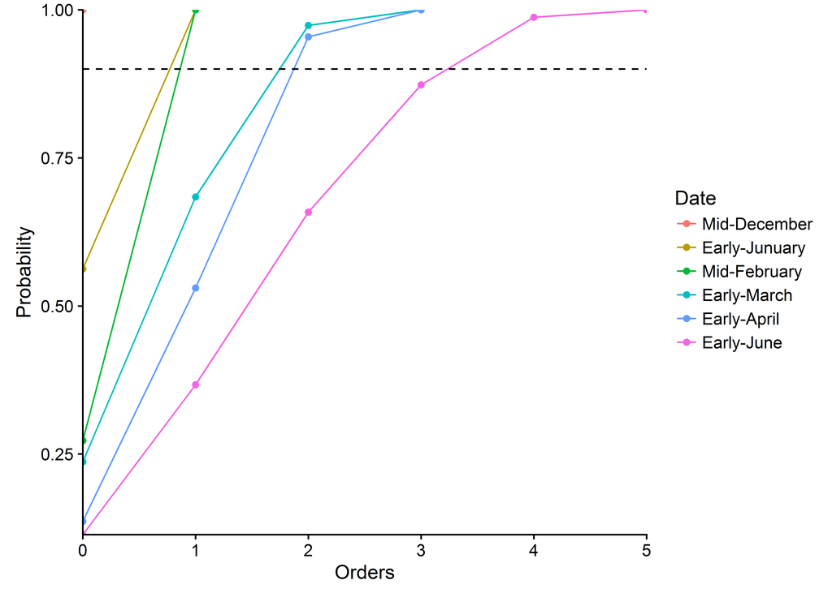

Module order frequency distribution for successive date

```r
fc_dist_order_by_date.plot(data=tab2)+
  geom_hline(yintercept = 0.9,linetype="dashed")
```

### 3.2.3 Cumulative distribution of one varname for each module order

- Table of distribution of one varname according to module orders

```r
tab3<-fc_dist_variable_by_order(data = dat,genotype = "Gariguette",varname = "nb_total_leaves",prob = "cumulative")

kable(x = tab3,
      caption = "Cumulative distribution of total no. leaves by orders",digits = 2)
```

Cumulative distribution of total no. leaves by orders

|  | 0 | 1 | 2 | 3 | 4 | 5 |
| --- | --- | --- | --- | --- | --- | --- |
| 1 | 0.00 | 0.01 | 0.00 | 0.00 | 0.00 | 0 |
| 2 | 0.00 | 0.31 | 0.16 | 0.24 | 0.22 | 0 |
| 3 | 0.02 | 0.68 | 0.65 | 0.95 | 1.00 | 1 |
| 4 | 0.02 | 0.82 | 0.76 | 1.00 | NA | NA |
| 5 | 0.02 | 0.91 | 0.89 | NA | NA | NA |
| 6 | 0.02 | 0.99 | 0.95 | NA | NA | NA |
| 7 | 0.04 | 1.00 | 0.97 | NA | NA | NA |
| 8 | 0.17 | 1.00 | 0.97 | NA | NA | NA |
| 9 | 0.35 | 1.00 | 1.00 | NA | NA | NA |
| 10 | 0.50 | 1.00 | NA | NA | NA | NA |
| 11 | 0.78 | 1.00 | NA | NA | NA | NA |
| 12 | 0.87 | 1.00 | NA | NA | NA | NA |
| 13 | 0.91 | 1.00 | NA | NA | NA | NA |
| 14 | 0.96 | 1.00 | NA | NA | NA | NA |
| 15 | 0.98 | 1.00 | NA | NA | NA | NA |
| 19 | 1.00 | 1.00 | NA | NA | NA | NA |

- Visualization of distribution of varname for each module orders

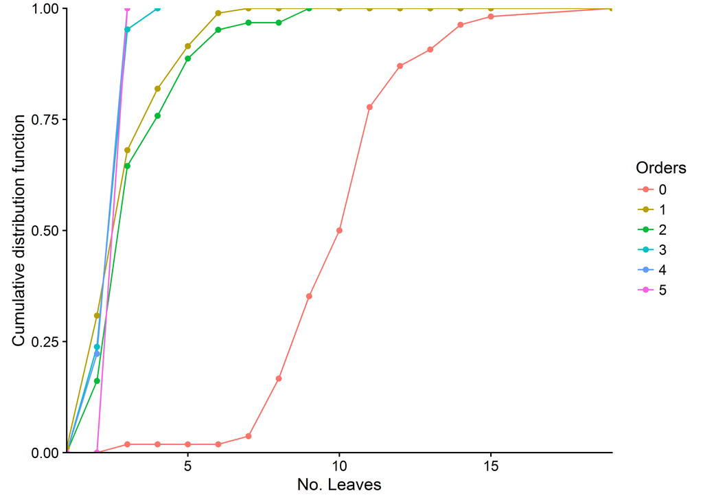

```r
fc_dist_variable_by_order.plot(data = tab3)+
  xlab("No. Leaves")+
  ylab("Cumulative distribution function")
```

### 3.2.4 Variable function of successive orders

In the following architectural analyses, we chose to group the highest-order modules because of the small sample size (cf. tables 1: No. Module by varieties for successive orders).

- Build data according group

```r
dat_group<-data[2:colend]



for (i in 1:nrow(data)){
  if( dat_group[i,"genotype"]=="Capriss"){
    if (data[i,'Index']=="0"){
      dat_group[i,"Index"]<- 0
      }else if (data[i,'Index']=="0-1"){
      dat_group[i,"Index"]<- 1
      }else if (data[i,'Index']=="0-1-2"){
        dat_group[i,"Index"]<- 2
      }else if (data[i,'Index']=="0-1-2-3"){
        dat_group[i,"Index"]<- 3
      }else if (data[i,'Index']=="0-1-2-3-4"){
        dat_group[i,"Index"]<- 3
      }else if (data[i,'Index']=="0-1-2-3-4-5"){
        dat_group[i,"Index"]<- 3
      }else if (data[i,'Index']=="1"){
        dat_group[i,"Index"]<- 1
      }else if (data[i,'Index']=="1-2"){
        dat_group[i,"Index"]<- 2
      }else if (data[i,'Index']=="1-2-3"){
        dat_group[i,"Index"]<- 3
      }else if (data[i,'Index']=="1-2-3-4"){
        dat_group[i,"Index"]<- 3
      }else if (data[i,'Index']=="1-2-3-4-5"){
        dat_group[i,"Index"]<- 3
      }else if (data[i,'Index']=="2"){
        dat_group[i,"Index"]<- 2
      }else if (data[i,'Index']=="2-3"){
        dat_group[i,"Index"]<- 3
      }else if (data[i,'Index']=="2-3-4"){
        dat_group[i,"Index"]<- 3
      }else if (data[i,'Index']=="3"){
        dat_group[i,"Index"]<- 3
      }else if (data[i,'Index']=="3-4"){
        dat_group[i,"Index"]<- 3
      }else if (data[i,'Index']=="4"){
        dat_group[i,"Index"]<- 3
      }
    }else
  if (data[i,'Index']=="0"){
    dat_group[i,"Index"]<- 0
  }else if (data[i,'Index']=="0-1"){
    dat_group[i,"Index"]<- 1
  }else if (data[i,'Index']=="0-1-2"){
    dat_group[i,"Index"]<- 2
  }else if (data[i,'Index']=="0-1-2-3"){
    dat_group[i,"Index"]<- 3
  }else if (data[i,'Index']=="0-1-2-3-4"){
    dat_group[i,"Index"]<- 4
  }else if (data[i,'Index']=="0-1-2-3-4-5"){
    dat_group[i,"Index"]<- 4
  }else if (data[i,'Index']=="1"){
    dat_group[i,"Index"]<- 1
  }else if (data[i,'Index']=="1-2"){
    dat_group[i,"Index"]<- 2
  }else if (data[i,'Index']=="1-2-3"){
    dat_group[i,"Index"]<- 3
  }else if (data[i,'Index']=="1-2-3-4"){
    dat_group[i,"Index"]<- 4
  }else if (data[i,'Index']=="1-2-3-4-5"){
    dat_group[i,"Index"]<- 4
  }else if (data[i,'Index']=="2"){
    dat_group[i,"Index"]<- 2
  }else if (data[i,'Index']=="2-3"){
    dat_group[i,"Index"]<- 3
  }else if (data[i,'Index']=="2-3-4"){
    dat_group[i,"Index"]<- 4
  }else if (data[i,'Index']=="3"){
    dat_group[i,"Index"]<- 3
  }else if (data[i,'Index']=="3-4"){
    dat_group[i,"Index"]<- 4
  }else if (data[i,'Index']=="4"){
    dat_group[i,"Index"]<- 4
  }
}

#Remplacer les valeurs 0 dans la colone total flowers par NA
dat_group$nb_total_flowers[dat_group$nb_total_flowers==0]<-NA

dat_group$Index<-as.factor(dat_group$Index)
```

- check that the modules have been well grouped

```r
tab4<- fc_dist_module_by_order(data = dat_group,index = "Index")
kable(x = tab4,caption = "Number of modules for each successive orders after grouping for each varieties")
```

Number of modules for each successive orders after grouping for each varieties

|  | 0 | 1 | 2 | 3 | 4 | Frequency |
| --- | --- | --- | --- | --- | --- | --- |
| Gariguette | 54 | 94 | 62 | 21 | 10 | 241 |
| Ciflorette | 54 | 115 | 78 | 31 | 20 | 298 |
| Clery | 54 | 98 | 63 | 34 | 14 | 263 |
| Capriss | 54 | 190 | 102 | 35 | 0 | 381 |
| Darselect | 54 | 87 | 57 | 39 | 9 | 246 |
| Cir107 | 54 | 154 | 110 | 41 | 8 | 367 |
| Frequency | 324 | 738 | 472 | 201 | 61 | 1796 |

[**Hint:** Compare tab4 with tab1]

#### 3.2.4.1 Recalculate data_at_module_scale after grouping

```r
data_at_module_scale_group<-ddply(.data = dat_group,
                                  .variables = c("genotype","Index"),
                                  summarise,
                                  MeanTotalLeave= mean(x = nb_total_leaves,
                                                       na.rm = T),
                                  SdTotalLeave= sd(x = nb_total_leaves,
                                                   na.rm = T),
                                  MeanTotalFlower= mean(x = nb_total_flowers,
                                                        na.rm = T),
                                  SdTotalFlower= sd(x = nb_total_flowers,
                                                    na.rm = T),
                                  MeanStolon= mean(x = stolons,
                                                   na.rm = T),
                                  SdStolon= sd(x = stolons,
                                               na.rm = T),
                            N=length(nb_total_leaves))

kable(x = data_at_module_scale_group,caption = " Data at module scale after grouping",digits = 2)
```

Data at module scale after grouping

| genotype | Index | MeanTotalLeave | SdTotalLeave | MeanTotalFlower | SdTotalFlower | MeanStolon | SdStolon | N |
| --- | --- | --- | --- | --- | --- | --- | --- | --- |
| Gariguette | 0 | 10.43 | 2.35 | 18.71 | 3.70 | 0.67 | 0.75 | 54 |
| Gariguette | 1 | 3.28 | 1.28 | 8.20 | 3.25 | 0.00 | 0.00 | 94 |
| Gariguette | 2 | 3.66 | 1.55 | 6.85 | 2.41 | 0.10 | 0.65 | 62 |
| Gariguette | 3 | 2.81 | 0.51 | 6.08 | 1.61 | 0.29 | 0.56 | 21 |
| Gariguette | 4 | 2.80 | 0.42 | 5.30 | 1.25 | 1.20 | 0.79 | 10 |
| Ciflorette | 0 | 7.63 | 2.57 | 10.95 | 2.76 | 1.09 | 0.96 | 54 |
| Ciflorette | 1 | 3.33 | 0.90 | 6.66 | 2.06 | 0.00 | 0.00 | 115 |
| Ciflorette | 2 | 3.60 | 1.01 | 5.95 | 1.64 | 0.00 | 0.00 | 78 |
| Ciflorette | 3 | 2.94 | 0.63 | 5.89 | 1.85 | 0.87 | 0.85 | 31 |
| Ciflorette | 4 | 3.75 | 1.65 | 6.71 | 1.33 | 1.80 | 0.77 | 20 |
| Clery | 0 | 8.33 | 2.97 | 13.71 | 3.34 | 1.65 | 1.25 | 54 |
| Clery | 1 | 3.09 | 1.04 | 6.34 | 2.13 | 0.01 | 0.10 | 98 |
| Clery | 2 | 3.46 | 0.78 | 4.24 | 1.46 | 0.10 | 0.35 | 63 |
| Clery | 3 | 2.94 | 0.65 | 4.35 | 1.30 | 0.38 | 0.70 | 34 |
| Clery | 4 | 2.86 | 0.77 | 3.89 | 1.17 | 0.79 | 0.70 | 14 |
| Capriss | 0 | 10.35 | 1.82 | 11.92 | 2.87 | 1.96 | 0.97 | 54 |
| Capriss | 1 | 3.43 | 1.04 | 4.28 | 1.28 | 0.00 | 0.00 | 190 |
| Capriss | 2 | 3.86 | 0.94 | 3.71 | 1.23 | 0.01 | 0.10 | 102 |
| Capriss | 3 | 2.91 | 0.74 | 3.33 | 0.82 | 0.20 | 0.41 | 35 |
| Darselect | 0 | 6.11 | 2.29 | 10.50 | 4.77 | 0.94 | 1.11 | 54 |
| Darselect | 1 | 3.34 | 1.08 | 7.69 | 3.03 | 0.01 | 0.11 | 87 |
| Darselect | 2 | 2.84 | 0.96 | 5.09 | 1.27 | 0.09 | 0.34 | 57 |
| Darselect | 3 | 2.56 | 0.68 | 5.00 | 0.79 | 0.23 | 0.48 | 39 |
| Darselect | 4 | 2.89 | 1.96 | 4.43 | 0.79 | 0.67 | 1.00 | 9 |
| Cir107 | 0 | 9.63 | 3.29 | 16.00 | 4.20 | 1.83 | 1.33 | 54 |
| Cir107 | 1 | 3.75 | 1.61 | 8.98 | 3.46 | 0.03 | 0.25 | 154 |
| Cir107 | 2 | 3.02 | 0.94 | 6.90 | 1.90 | 0.00 | 0.00 | 110 |
| Cir107 | 3 | 3.27 | 0.71 | 5.44 | 1.50 | 0.29 | 0.56 | 41 |
| Cir107 | 4 | 3.88 | 2.10 | 5.17 | 0.98 | 1.00 | 0.76 | 8 |

#### 3.2.4.2 Pointwise Mean of variable of modules for successive orders for each varieties

```r
fc_pointwise_mean_variable_by_order(data = data_at_module_scale_group,varname = "MeanTotalLeave")+
  ylab("Mean No. Leaves")+
  ylim(2,10)
```

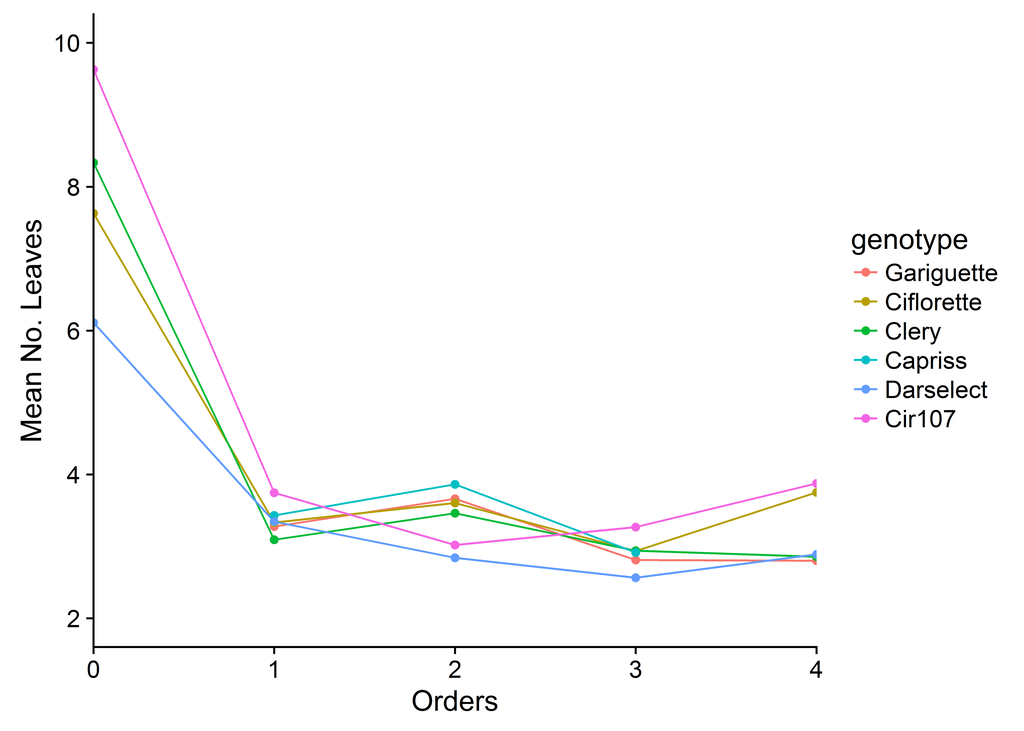

### 3.2.5 Comparison of variable for successive orders

Because pointwise of the mean no.leaves and mean no.flowers seems roughly constant for each varieties. In order to compare varieties we used trend linear regression, in particular we test the zero value of the slope parameter.

#### 3.2.5.1 *First step:* Identification from wich module variable was roughly constant for each varieties

- **From Order 0**

```r
Gariguette<- fc_linear_trend_reg(data = dat_group,
                                 genotype = "Gariguette",
                                 variable = "nb_total_leaves",
                                 Index = "Index")

Clery<- fc_linear_trend_reg(data = dat_group,
                            genotype = "Gariguette",
                            variable = "nb_total_leaves",
                            Index = "Index")

Capriss<- fc_linear_trend_reg(data = dat_group,
                              genotype = "Capriss",
                              variable = "nb_total_leaves",
                              Index = "Index")

Ciflorette<- fc_linear_trend_reg(data = dat_group,
                                 genotype = "Ciflorette",
                                 variable = "nb_total_leaves",
                                 Index = "Index")

Cir107<- fc_linear_trend_reg(data = dat_group,
                             genotype = "Cir107",
                             variable = "nb_total_leaves",
                             Index = "Index")

Darselect<- fc_linear_trend_reg(data = dat_group,
                                genotype = "Darselect",
                                variable = "nb_total_leaves",
                                Index = "Index")

tab5<- merge(x = Gariguette,y = Clery,all=T)
tab5<- merge(x = tab5,y = Capriss, all=T)
tab5<- merge(x = tab5,y = Ciflorette, all=T)
tab5<- merge(x = tab5,y = Cir107, all=T)
tab5<- merge(x = tab5,y = Darselect, all=T)

kable(x = tab5,digits = 2,caption = "Linear trend (estimate slope and 95% confidence interval -IC95%-)")
```

Linear trend (estimate slope and 95% confidence interval -IC95%-)

| Genotype | Slope | IC_lower | IC_upper |
| --- | --- | --- | --- |
| Capriss | -1.89 | -2.15 | -1.62 |
| Ciflorette | -0.91 | -1.11 | -0.71 |
| Cir107 | -1.62 | -1.87 | -1.36 |
| Darselect | -0.96 | -1.14 | -0.78 |
| Gariguette | -2.00 | -2.32 | -1.68 |

- **From Order 1**

```r
dat_group_from_Order1<-dat_group[!dat_group[,'Index']=="0",]

Gariguette<- fc_linear_trend_reg(data = dat_group_from_Order1,
                                 genotype = "Gariguette",
                                 variable = "nb_total_flowers",
                                 Index = "Index")

Clery<- fc_linear_trend_reg(data = dat_group_from_Order1,
                            genotype = "Gariguette",
                            variable = "nb_total_flowers",
                            Index = "Index")

Capriss<- fc_linear_trend_reg(data = dat_group_from_Order1,
                              genotype = "Capriss",
                              variable = "nb_total_flowers",
                              Index = "Index")

Ciflorette<- fc_linear_trend_reg(data = dat_group_from_Order1,
                                 genotype = "Ciflorette",
                                 variable = "nb_total_flowers",
                                 Index = "Index")

Cir107<- fc_linear_trend_reg(data = dat_group_from_Order1,
                             genotype = "Cir107",
                             variable = "nb_total_flowers",
                             Index = "Index")

Darselect<- fc_linear_trend_reg(data = dat_group_from_Order1,
                                genotype = "Darselect",
                                variable = "nb_total_flowers",
                                Index = "Index")

tab6<- merge(x = Gariguette,y = Clery,all=T)
tab6<- merge(x = tab6,y = Capriss, all=T)
tab6<- merge(x = tab6,y = Ciflorette, all=T)
tab6<- merge(x = tab6,y = Cir107, all=T)
tab6<- merge(x = tab6,y = Darselect, all=T)

kable(x = tab6,digits = 2,caption = "Linear trend (estimate slope and 95% confidence interval -IC95%-)")
```

Linear trend (estimate slope and 95% confidence interval -IC95%-)

| Genotype | Slope | IC_lower | IC_upper |
| --- | --- | --- | --- |
| Capriss | -0.50 | -0.75 | -0.25 |
| Ciflorette | -0.18 | -0.47 | 0.10 |
| Cir107 | -1.65 | -2.14 | -1.17 |
| Darselect | -1.31 | -1.76 | -0.87 |
| Gariguette | -1.03 | -1.55 | -0.51 |

- **From Order 2**

```r
dat_group_from_Order2<-dat_group_from_Order1[!dat_group_from_Order1[,'Index']=="1",]

Gariguette<- fc_linear_trend_reg(data = dat_group_from_Order2,
                                 genotype = "Gariguette",
                                 variable = "nb_total_flowers",
                                 Index = "Index")

Clery<- fc_linear_trend_reg(data = dat_group_from_Order2,
                            genotype = "Gariguette",
                            variable = "nb_total_flowers",
                            Index = "Index")

Capriss<- fc_linear_trend_reg(data = dat_group_from_Order2,
                              genotype = "Capriss",
                              variable = "nb_total_flowers",
                              Index = "Index")

Ciflorette<- fc_linear_trend_reg(data = dat_group_from_Order2,
                                 genotype = "Ciflorette",
                                 variable = "nb_total_flowers",
                                 Index = "Index")

Cir107<- fc_linear_trend_reg(data = dat_group_from_Order2,
                             genotype = "Cir107",
                             variable = "nb_total_flowers",
                             Index = "Index")

Darselect<- fc_linear_trend_reg(data = dat_group_from_Order2,
                                genotype = "Darselect",
                                variable = "nb_total_flowers",
                                Index = "Index")

tab7<- merge(x = Gariguette,y = Clery,all=T)
tab7<- merge(x = tab7,y = Capriss, all=T)
tab7<- merge(x = tab7,y = Ciflorette, all=T)
tab7<- merge(x = tab7,y = Cir107, all=T)
tab7<- merge(x = tab7,y = Darselect, all=T)

kable(x = tab7,digits = 2,caption = "Linear trend (estimate slope and 95% confidence interval -IC95%-)")
```

Linear trend (estimate slope and 95% confidence interval -IC95%-)

| Genotype | Slope | IC_lower | IC_upper |
| --- | --- | --- | --- |
| Capriss | -0.37 | -0.94 | 0.19 |
| Ciflorette | 0.29 | -0.19 | 0.77 |
| Cir107 | -1.13 | -1.73 | -0.53 |
| Darselect | -0.25 | -0.64 | 0.14 |
| Gariguette | -0.78 | -1.49 | -0.06 |